# DV_SProject: Shiny app for Refugee Flow

[figure not shown]

## 00. Create/Clone a github repository

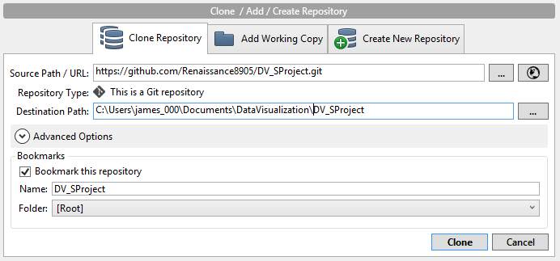

## 01. Create RStudio Project

[figure not shown]

## 02. Setup RStudio

Create three folders in RStudio Project:  
- **00 Doc**: where .Rmd and graphics folder live  
- **01 Data**: where data, csv’s will be stored  
- **02 Shiny**: Shiny app development

## 03. Download .CSV Files

Data taken from http://popstats.unhcr.org/

[figure not shown]

## 04. ETL & Create Table on Database

CREATE TABLE Refugee_Stats ( Asylum_Country varchar2(4000), Origin_Country varchar2(4000), Record_Year number(38,4), Refugees number(38,4), Asylum_seekers number(38,4), Returned_Refugees number(38,4), IDPs number(38,4), Returned_IDPs number(38,4), Stateless_persons number(38,4), Others_of_concern number(38,4), Total_Population number(38,4) );

CREATE TABLE Yearly_Pop_By_Country ( – Change table_name to the table name you want. Country_Name varchar2(4000), Country_Code varchar2(4000), Indicator_Name varchar2(4000), Indicator_Code varchar2(4000), X1960 number(38,4), X1961 number(38,4), X1962 number(38,4), X1963 number(38,4), X1964 number(38,4), X1965 number(38,4), X1966 number(38,4), X1967 number(38,4), X1968 number(38,4), X1969 number(38,4), X1970 number(38,4), X1971 number(38,4), X1972 number(38,4), X1973 number(38,4), X1974 number(38,4), X1975 number(38,4), X1976 number(38,4), X1977 number(38,4), X1978 number(38,4), X1979 number(38,4), X1980 number(38,4), X1981 number(38,4), X1982 number(38,4), X1983 number(38,4), X1984 number(38,4), X1985 number(38,4), X1986 number(38,4), X1987 number(38,4), X1988 number(38,4), X1989 number(38,4), X1990 number(38,4), X1991 number(38,4), X1992 number(38,4), X1993 number(38,4), X1994 number(38,4), X1995 number(38,4), X1996 number(38,4), X1997 number(38,4), X1998 number(38,4), X1999 number(38,4), X2000 number(38,4), X2001 number(38,4), X2002 number(38,4), X2003 number(38,4), X2004 number(38,4), X2005 number(38,4), X2006 number(38,4), X2007 number(38,4), X2008 number(38,4), X2009 number(38,4), X2010 number(38,4), X2011 number(38,4), X2012 number(38,4), X2013 number(38,4), X2014 number(38,4) );